# Project 2 - M3 Data

Nicholas Nasser

2024-02-13

## Introduction

##### The dataset I will be using for this project was compiled using a website dedicated to car auctions called Cars & Bids. Potential customers looking at cars listed on this site have access to plenty of information about each car such as current mileage, transmission type, body style, and more. For my dataset, I will be looking specifically at BMW M3s from 2008 to 2013 that have been auctioned on Cars & Bids. The variables of the dataset will consist of particular pieces of information about each BMW such as those listed previously. To access the site, click on the link below.

[Cars & Bids: BMW M3 Link](https://carsandbids.com/search?q=bmw%20m3%20e9x)

[figure not shown]

Source - Chilton, Chris. “North America Didn’t Get The Incredible E92 BMW M3 GTS, But You Can Buy This Convincing Clone.” *Carscoops*, April 2022. https://www.carscoops.com. (Full Link Located at end of Project.)

##### I picked this dataset to analyze because I am particularly interested in this vehicle, so much so that I plan to buy one in the future. I will be investigating the impact of different factors such as mileage, transmission type, body style, exterior and interior color, and more on the resale value of this specific M3.

## Data Preparation

##### I obtained my data by manually inputting each observation into a Microsoft Excel spreadsheet before converting it to a CSV file and importing it into R. This method was extremely inefficient, but due to technical difficulties I was not able to scrape my data using the selector gadget.

##### Once I imported the data, the following measures were taken to process it:

##### - I converted the max bid and mileage columns from integer variables to numeric variables to make future numerical manipulation involving decimals smoother.

##### - I changed the Car Sold and Competition Package variables to logical variables since they were initally imported as character variables.

##### - I created two new variables called Miles per Dollar and Low Mileage.

##### - I renamed all of the variables in the dataset because each variable that had multiple words was initially separated by a period. This makes the variables easier to read.

##### - I utilized a for loop to add each formal M3 model indicator to the Body Style Variable. E93 refers to convertible, E92 refers to coupe, and E90 refers to sedan. See Section 7 for reasoning.

##### As mentioned above, one challenge I had was that I could not scrape my data so I inputted each observation into my dataset manually. This took a long time and increased the risk for mistakes. As for NA values, there was only one such occurrence where an auction had been cancelled. I dealt with this by simply removing it from the dataset, which left me with 113 total observations.

## Variable Descriptions

##### Below is a table with the name, type, and brief description of each variable of interest from the original M3 dataset.

M3 Data Variables

| Variables | Data Type | Variable Description |
| --- | --- | --- |
| Max Bid Price | Numeric | Maximum price that a customer bid for the vehicle, regardless of if it sold. |
| Car Sold | Logical | Whether or not the vehicle sold; whether or not the reserve price was met. |
| Transmission | Character | Type of transmission - either a 6 speed manual or dual clutch 7 speed automatic. |
| Mileage | Numeric | Amount of miles the vehicle has on the odometer at the time of auction. |
| Body Style | Character | If the vehicle is Coupe, Convertible, or Sedan. |
| Miles Per Dollar | Numeric | Amount of miles driven for every dollar bid on the vehicle. |
| Low Mileage | Logical | Vehicles with under 50,000 miles. |

## Univariate Analyses

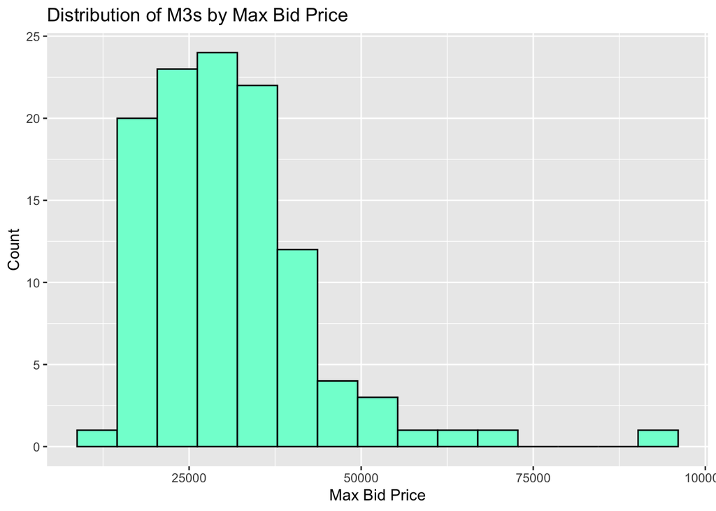

##### The graph above deals with the Max Bid Price variable, which is skewed heavily to the right with a long tail towards the highest values. The mean value for this variable is $30859.73, with standard deviation from the mean being $12228.19. These descriptive statistics demonstrate that the resale price of these M3s are often cheaper than new cars today, and they underscore the instances in which an M3 from this time period sells for over $50000.

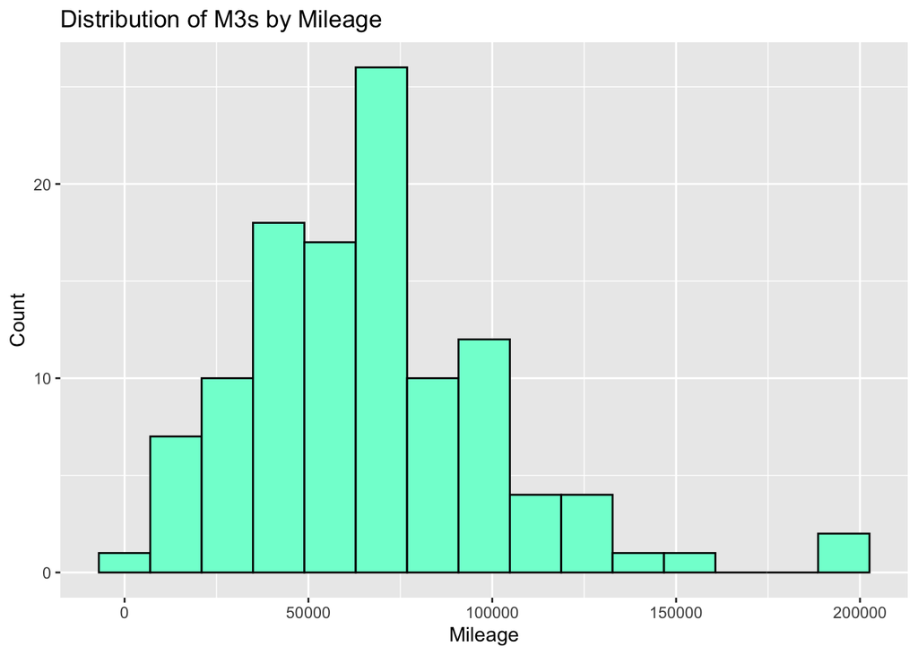

##### The graph above deals with the Mileage variable, which is also skewed heavily to the right with a long tail towards the highest values. The mean value for this variable is 66662.35 miles, with a standard deviation from the mean being 35103.17 miles. These descriptive statistics demonstrate a wide range of possible mileages that an M3 from this time could have, indicating that some previous owners may look after their M3s more by driving it less, while others use it as a daily vehicle.

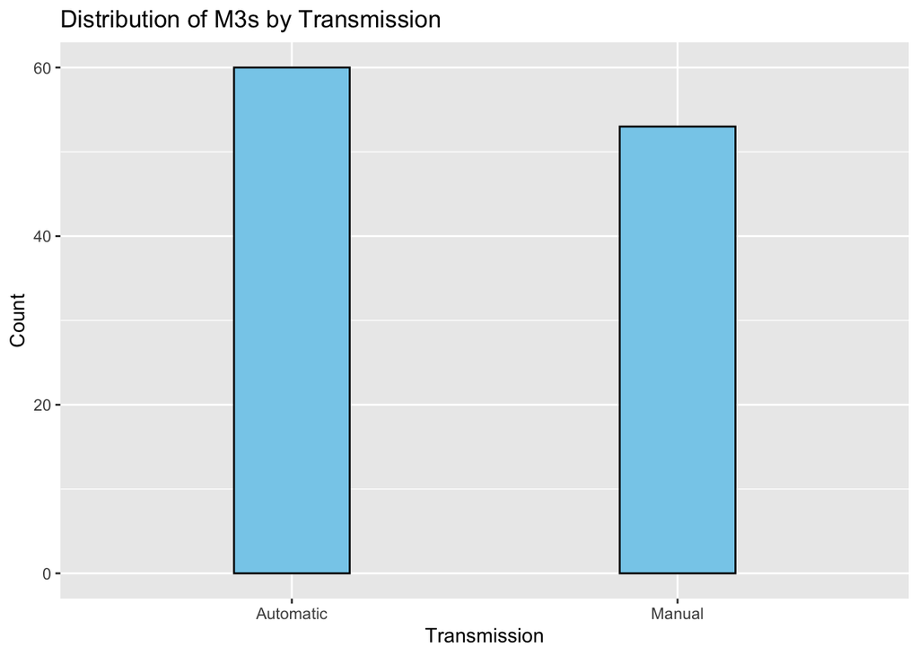

##### The graph above deals with the Transmission variable, which is not particularly skewed in any direction as the number of M3s auctioned with an automatic transmission was highly similar to the number of M3s auctioned with a manual transmission. However, we can see that cars with an automatic transmission were auctioned slightly more (maximum value), with 60 being exact the amount. Cars with a manual transmission (minimum value) were auctioned 53 times. This distribution demonstrates that the choice of transmission is highly dependent on the preference of the buyer.

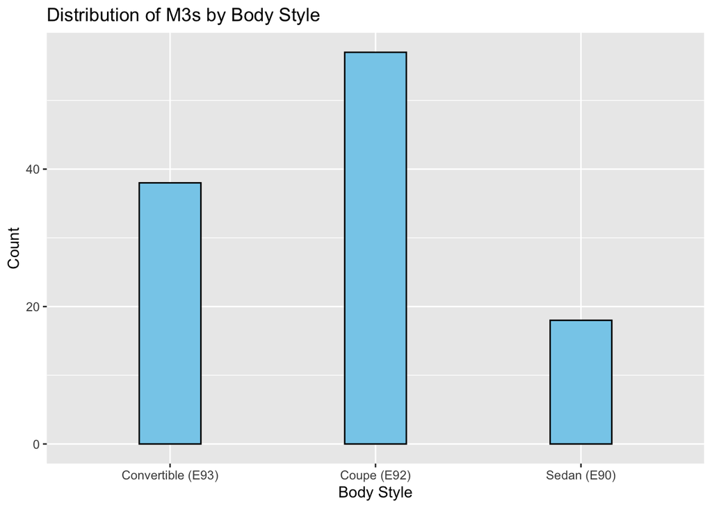

##### The graph above deals with the Body Style variable, which is slightly skewed to the right. The most prevalent body style was the two door Coupe (maximum value), with 57 instances in the dataset. The least prevalent body style was the four door Sedan (minimum value), with 18 instances in the dataset. Two door convertibles (median) fell right into between the other two body styles, with 38 instances in the dataset. After observing this graph, it is clear that the two door options are more popular than the four door sedan.

## Multivariate Analyses

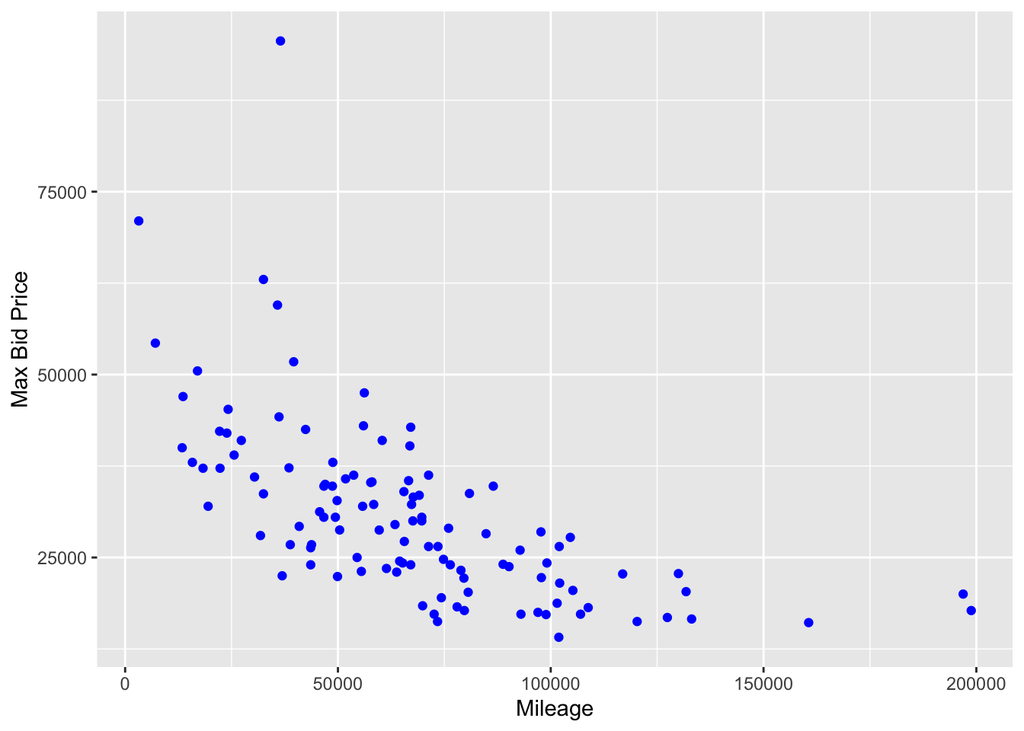

##### The graph above displays an inverse relationship between the mileage of an M3 and its Maximum Bid Price. Besides one outlier that was bid for past $80,000, this trend was extremely consistent. The correlation coefficient between these two variables is -0.62, which indicates a strong negative correlation.

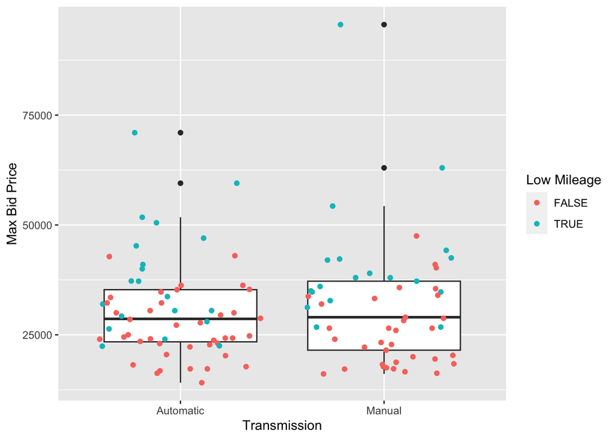

##### The graph above displays the distribution of max bid prices by transmission. It also further organizes the data by whether or not the vehicles had under 50000 miles on the odometer. Disregarding the outlier for the manual transmission boxplot, the distribution of points are extremely similar, signaling no real correlation between max bid price and transmission type. Below are five number summaries for automatic and manual transmissions respectively.

```
## [1] 14100 23300 28625 35292 71000
```

```
## [1] 16100 21499 29000 37200 95600
```

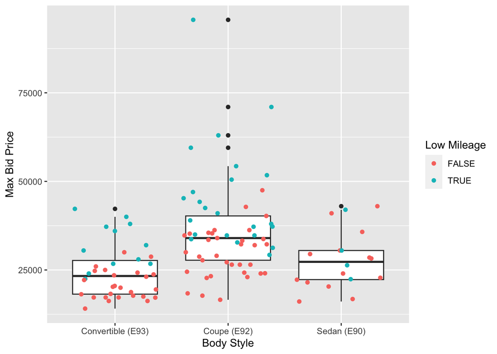

##### The graph above displays the distribution of max bid prices by body style. It also further organizes the data by whether or not the vehicles had under 50000 miles on the odometer. By observing the graph, it is clear that on average the coupe body style received the highest maximum bids, many of which were higher than some convertible and sedan M3s with considerably lower mileages. Below are five number summaries for convertible, coupe, and sedan body styles respectively.

```
## [1] 14100 18150 23300 28000 42250
```

```
## [1] 16592 27750 34000 40250 95600
```

```
## [1] 16100 22250 27292 30500 43000
```

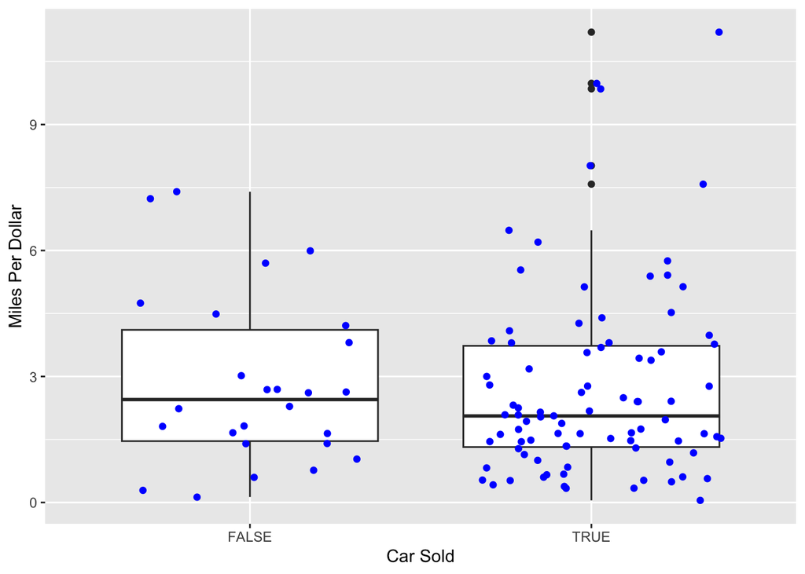

```
## [1]  0.05  1.32  2.06  3.73 11.20
```

```
## [1] 0.13 1.40 2.45 4.21 7.40
```

## Reproducibility

##### In order to ensure reproducbility of this project, I made sure to make plenty of commentary as I coded. I also made sure to limit the amount of external files one would need to have in their directory to knit the project correctly. As of now, the only files needed are the jpeg for the picture at the beginning of the project and the M3 dataset.

## Choice Elements

##### For my first choice element, I used more than 5 inline codes throughout the project. The first instance shows up in the data preparation section, where I used inline code to print the number of observations in my initial dataset. The rest of the instances they show up in are the descriptions of multiple univariate and multivariate graphs, where I used them to include specific descriptive statistics.

##### For my second choice element, I chose to create two new variables of interest. The first variable I chose to create was miles per dollar, which was calculated by dividing a vehicle’s mileage by its maximum bid price. As mentioned previously, this variable can hint at potential reliability of a vehicle. The second variable I chose to create was called Low Mileage, which was a logical variable that marked observations true if the vehicle had under 50000 miles, and false otherwise. I used this variable to add depth of information to two of my multivariate graphs.

##### For my third choice element, I used a loop to add the formal M3 model indicators - E90, E92, and E93 - to their corresponding body types. E90 refers to the sedan body type, E92, refers to the coupe body type, and E93 refers to the convertible body type. This was done in the hopes of eliminating any confusion that might arise if a viewer of the dataset sees these specific indicators online without their corresponding body types.

##### For my fourth choice element, I wrote a function capable of receiving two arguments that makes graphing numeric and character variables in a univariate manner quicker and easier. All the user has to do is enter the variable they want to graph, as well as the variable name that will be inserted into the title and x - axis label. This function only takes variables that are numeric or character, but the use of if statements allows for endless other graphing options.

##### For my fifth element which I briefly mentioned in the last paragraph, I used an if statement in my function to graph univariate variables. This allows the user to input variables of different data types, which will be graphed differently depending on the code after each if statement.

## Conclusion

##### In conclusion, I determined that though there are many various factors that go into purchasing a BMW M3 E9X, only a handful of them truly reflect what specific car to look at. Some of the variables I observed ended up simply being a matter of personal preference, or they just were not factors important enough to most potential buyers.

##### For example, when looking at the relationship between miles per dollar and whether or not the cars sold, the boxplots turned out to be extremely similar, indicating a lack of customer interest for how many miles a car had driven in comparison to how much they bid. I thought this would have been a much more useful variable in determining reliability of the vehicle. Similarly, when looking at max bid price by transmission, the data did not reflect any major differences in pricing. However, unlike the miles per dollar variable, I expected this was possible as the transmission does not have a large affect on the performance of the vehicle, but rather the feel.

##### The two variables of interest that did produce useable results were mileage and body style. When comparing mileage to max bid price, there was a clear negative correlation between the two; as mileage goes up, bid price goes down. For me, this was obviously a result I expected to see. However, I was surprised when comparing body style to max bid prices when I found that coupes were clearly selling for more than sedans and convertibles. I interpreted this to be that most people interested in buying an E9X M3 in today’s market are looking for a performance vehicle, which can be achieved best with the E92 coupe.

## References

##### Chilton, Chris. “North America Didn’t Get The Incredible E92 BMW M3 GTS, But You Can Buy This Convincing Clone.” *Carscoops*, April 2022. [Source](https://www.carscoops.com/2022/04/north-america-didnt-get-the-incredible-e92-bmw-m3-gts-but-you-can-buy-this-convincing-clone/)

##### “BMW M3 E9X.” *Cars and Bids*, Accessed Oct. 25, 2023. [Source](https://carsandbids.com/search?q=bmw%20m3%20e9x)